# Analysis

This document describes the data analylsis of the FCT investigator calls for the period 2013-2015. For further information see https://www.fct.pt/apoios/contratacaodoutorados/investigador-fct/estatisticas.phtml.pt

```r
#Before we start we set up some things
library(xlsx)
library(httr)
library(jsonlite)
library(ggplot2)
rm(list=ls())# Cleaning up workspace before starting
setwd("/home/mops2/Work/projects/IF_report/git-hub-repo-if_report/")
```

```r
  # Utilities: Here are some useful functions.
  ##1. A master function that stats and creates a data directory and a log file to keep information on when downloads were made and sub-directories and files were created.
  # This function uses the working directory as reference
  make_data_directory <- function(directory_name){
    if(!file.exists(directory_name) & directory_name != "./" & directory_name != "." & directory_name != ""){
        dir.create(directory_name)
      dir_log <- file(paste(directory_name,"/directory.log",sep=""),"a")
      write(paste("Directory ",as.character(directory_name)," was created at ",system("date -u", intern = TRUE)), file = dir_log, append = TRUE)
        close(dir_log)
    }
    else if(directory_name == "./" | directory_name == "." | directory_name == ""){
        stop("Please specify a valid directory to hold your data!")
    }
    else{
        warning(paste("The",directory_name,"directory and directory.log already exist."))
    }
    directory_name
  }
```

```r
  #2. A function that stats for a sub-directory and creates it if necessary and writes and entry in the log.
  make_data_sub_directory <- function(directory_name, sub_directory_name){
    # make master directory first if necessary
    make_data_directory(directory_name)
    # Then move on to make this sub-directory
    rel_path <-paste(directory_name,"/",sub_directory_name,sep="")
    if(!file.exists(rel_path)){
      dir.create(rel_path)
      dir_log <- file(paste(directory_name,"/directory.log",sep=""),"a")
      write(paste("sub-directory",rel_path,"was created at ",system("date -u", intern = TRUE)), dir_log, append = TRUE)
      close(dir_log)
    }else{
      warning(paste("The",rel_path,"directory already exists."))
    }
    rel_path
  }
```

```r
#3. A function that stats for a downloaded file and downloads it if necessary and writes an entry in the log.
  make_data_file_download <- function(directory_name, sub_directory_name,url_path,filename){
    # make master directory first if necessary
    make_data_directory(directory_name)
    # make sub directory if necessary
    make_data_sub_directory(directory_name, sub_directory_name)
    # Then download file
    rel_path <-paste(directory_name,"/",sub_directory_name,sep="")
    rel_path_file <-paste(directory_name,"/",sub_directory_name,"/",filename,sep="")
    if(!file.exists(rel_path_file)){
      file_log <- file(paste(rel_path_file,".log",sep=""),"w")
      download.file(url_path, destfile  = rel_path_file)
      write(paste("File",rel_path_file,"was downloaded at",system("date -u", intern = TRUE),"from the following url: ",url_path), file_log)
      close(file_log)
    }else{
      warning(paste("The",rel_path_file,"file already exists."))
    }
    rel_path_file
  }
```

```r
# Multiple plot function
#
# ggplot objects can be passed in ..., or to plotlist (as a list of ggplot objects)
# - cols:   Number of columns in layout
# - layout: A matrix specifying the layout. If present, 'cols' is ignored.
#
# If the layout is something like matrix(c(1,2,3,3), nrow=2, byrow=TRUE),
# then plot 1 will go in the upper left, 2 will go in the upper right, and
# 3 will go all the way across the bottom.
#
multiplot <- function(..., plotlist=NULL, file, cols=1, layout=NULL) {
  library(grid)

  # Make a list from the ... arguments and plotlist
  plots <- c(list(...), plotlist)

  numPlots = length(plots)

  # If layout is NULL, then use 'cols' to determine layout
  if (is.null(layout)) {
    # Make the panel
    # ncol: Number of columns of plots
    # nrow: Number of rows needed, calculated from # of cols
    layout <- matrix(seq(1, cols * ceiling(numPlots/cols)),
                    ncol = cols, nrow = ceiling(numPlots/cols))
  }

 if (numPlots==1) {
    print(plots[[1]])

  } else {
    # Set up the page
    grid.newpage()
    pushViewport(viewport(layout = grid.layout(nrow(layout), ncol(layout))))

    # Make each plot, in the correct location
    for (i in 1:numPlots) {
      # Get the i,j matrix positions of the regions that contain this subplot
      matchidx <- as.data.frame(which(layout == i, arr.ind = TRUE))

      print(plots[[i]], vp = viewport(layout.pos.row = matchidx$row,
                                      layout.pos.col = matchidx$col))
    }
  }
}
```

# 1 Data loading

## 1.1 IF2013

Loading data and sample of first few lines

```r
  clean_data_dir <- "clean_data"
  clean_data_subdir2013 <- "2013"
  data2013<- read.csv(paste(clean_data_dir,"/",clean_data_subdir2013,"/clean_data2013.csv", sep = ""))
  head(data2013,3)
```

```
##             Ref                               Name Grade1 Grade3 Status1
## 1 IF/00003/2013          André Martinho De Almeida      7      7      No
## 2 IF/00004/2013             Susana de Sousa Araujo      6      6      No
## 3 IF/00005/2013 Christoph Friedrich Johannes Meyer      6      6      No
##   Status3 Rank1 Rank3
## 1      No   209   215
## 2      No   403   413
## 3      No   404   414
```

```r
  tail(data2013,3)
```

```
##                Ref                         Name Grade1 Grade3 Status1
## 1477 IF/01816/2013            Lyubchik Svetlana      6      6      No
## 1478 IF/01817/2013 Ricardo Angelo Rosa Vardasca      6      6      No
## 1479 IF/01822/2013       Katkam Nadpi Gangadhar      5      5      No
##      Status3 Rank1 Rank3
## 1477      No  1360  1368
## 1478      No  1361  1369
## 1479      No  1458  1459
```

## 1.2 IF2014

Loading data and sample of first few lines

```r
  clean_data_dir <- "clean_data"
  clean_data_subdir2014 <- "2014"
  data2014<- read.csv(paste(clean_data_dir,"/",clean_data_subdir2014,"/clean_data2014.csv", sep = ""))
  head(data2014,3)
```

```
##             Ref                                   Name
## 1 IF/00003/2014 Luís Miguel Nunes Valente Afonso Reino
## 2 IF/00004/2014                           Karine Serre
## 3 IF/00006/2014                Manuel Algarra Gonzalez
##                                                                                 Host
## 1 Rede de Investigação em Biodiversidade e Biologia Evolutiva (InBIO/ICETA-Porto/UP)
## 2                                        Instituto de Medicina Molecular (IMM/FM/UL)
## 3                                    Centro de Investigação em Química (CIQ/FCUP/UP)
##   Panel Grade1 Rank1 Status1 Grade2 Rank2 Status2 Grade3 Rank3 Status3
## 1   nat    7.5   232     Yes    7.5   233     Yes    7.5   352     Yes
## 2   med    8.0    74     Yes    8.0    74     Yes    8.0   144     Yes
## 3 empty    6.5   698      No    6.5   703      No     NA    NA   empty
##   Grade4 WGrade4 Rank4 PanelRank4 Status4 Grade5 WGrade5 Rank5 PanelRank5
## 1      7     7.0   236         53 Reserve      7     7.0   237         53
## 2      8     8.5    81          7     Yes      8     8.5    81          7
## 3     NA      NA    NA         NA   empty     NA      NA    NA         NA
##   Status5 Grade6 WGrade6 Rank6 PanelRank6 Status6
## 1 Reserve      7     7.0   347         57 Reserve
## 2     Yes      8     8.5   157          8     Yes
## 3   empty     NA      NA    NA         NA   empty
```

```r
  tail(data2014,3)
```

```
##                Ref                              Name
## 1396 IF/01774/2014 Manuel Jacinto de Ascensão Jardim
## 1397 IF/01778/2014            ALICIA MIGUÉLEZ CAVERO
## 1398 IF/01780/2014 António Carlos Almeida Figueiredo
##                                                                      Host
## 1396 Centro de Literaturas e Culturas Lusófonas e Europeia (CLEPUL/FL/UL)
## 1397                        Instituto de Estudos Medievais (IEM/FCSH/UNL)
## 1398                   Instituto de Plasma e Fusão Nuclear (IPFN/IST/UTL)
##      Panel Grade1 Rank1 Status1 Grade2 Rank2 Status2 Grade3 Rank3 Status3
## 1396 empty    3.5  1381      No    3.5  1381      No     NA    NA   empty
## 1397 empty    6.0  1106      No    6.0  1107      No     NA    NA   empty
## 1398 empty    4.0  1367      No    4.0  1367      No     NA    NA   empty
##      Grade4 WGrade4 Rank4 PanelRank4 Status4 Grade5 WGrade5 Rank5
## 1396     NA      NA    NA         NA   empty     NA      NA    NA
## 1397     NA      NA    NA         NA   empty     NA      NA    NA
## 1398     NA      NA    NA         NA   empty     NA      NA    NA
##      PanelRank5 Status5 Grade6 WGrade6 Rank6 PanelRank6 Status6
## 1396         NA   empty     NA      NA    NA         NA   empty
## 1397         NA   empty     NA      NA    NA         NA   empty
## 1398         NA   empty     NA      NA    NA         NA   empty
```

## 1.3 IF2015

Loading data and sample of first few lines

```r
  clean_data_dir <- "clean_data"
  clean_data_subdir2015 <- "2015"
  data2015<- read.csv(paste(clean_data_dir,"/",clean_data_subdir2015,"/clean_data2015.csv", sep = ""))
  head(data2015,3)
```

```
##             Ref                            Name
## 1 IF/00001/2015        Jose Manuel Herrera Vega
## 2 IF/00005/2015         ENRIQUE CERRILLO CUENCA
## 3 IF/00006/2015 Romana Lopes Almeida dos Santos
##                                                                                      Host
## 1                                                              Universidade de Évora (UE)
## 2 Centro de História de Arte e Investigação Artística da Universidade de Évora (CHAIA/UE)
## 3                                 Faculdade de Ciências da Universidade de Lisboa (FC/UL)
##   Panel Grade1 Rank1 Status1 Grade2 Rank2 Status2 Grade3 WGrade3 CVGrade3
## 1   nat    7.0   452     Yes    7.0   455     Yes      8     7.6        8
## 2 empty    6.5   694      No    6.5   700      No     NA      NA       NA
## 3   nat    7.5   247     Yes    7.5   248     Yes      8     7.9        7
##   ResearchGrade3 CareerPlanGrade3 Rank3 PanelRank3 Status3
## 1              7                8   235         20     Yes
## 2             NA               NA    NA         NA   empty
## 3              9                8   233         18     Yes
```

```r
  tail(data2015,3)
```

```
##                Ref                                 Name
## 1365 IF/01697/2015                    Lyubchik Svetlana
## 1366 IF/01698/2015 Stanislav Konstantinovich Kondratyev
## 1367 IF/01699/2015                        Cédric Camier
##                                                                                        Host
## 1365 Laboratório Associado para a Química Verde - Tecnologias e Processos Limpos (REQUIMTE)
## 1366                                                       Centro de Matemática (CM/FCT/UC)
## 1367                                                 INESC Tecnologia e Ciência (INESC TEC)
##      Panel Grade1 Rank1 Status1 Grade2 Rank2 Status2 Grade3 WGrade3
## 1365 empty    4.5  1332      No    4.5  1338      No     NA      NA
## 1366 empty    6.5   973      No    6.5   978      No     NA      NA
## 1367 empty    6.5   974      No    6.5   979      No     NA      NA
##      CVGrade3 ResearchGrade3 CareerPlanGrade3 Rank3 PanelRank3 Status3
## 1365       NA             NA               NA    NA         NA   empty
## 1366       NA             NA               NA    NA         NA   empty
## 1367       NA             NA               NA    NA         NA   empty
```

# 2 Exploratory analysis

The purpose of this section is to enumerate interesting questions that we may want to address in a detailed analysis and to quickly check if there is any hope to get any useful information on the possible answers to those questions. Let us first make a list:

- Description of populations and the distribution/acceptance rates by scientific area
  - Distributions of marks and rankings for global population and panels
  - Acceptance rates by panel vs global acceptance rates, maybe also by institution.
  - Year by year variability
  - Plot correlations
- Quality of the evaluation process:
  - What is the error of the Grades and the rankings?
  - How much can a candidate fluctuate up/down wards?
  - What is the expectation value for the number of candidates unfairly exlcuded at an early stage of the evaluation?
  - What is the error associated with the final ranking? (I am not even sure that there is a way to estimate this!) What is the expectation value of the number of candidates unfairly exluded in the final ranking?
- Bias (here it sounds like a good idea to apply a permutation test either to ranks or grade distributions for the label of interest – gender or host… maybe bootstrapping can also be a way to get confidence intervals?):
  - Compare cases of candidates that in one year tried one institute and another year another institute. To do this correctly I would probably need pairs of institutes with candidates moving both ways, otherwise it is note clear if this is just due to CV improvement.
  - Gender bias? Is there an easy way to determine the gender?

## 2.1 Gender information

There is a piece of information that is contained in the Name field that we can first try to retrieve. That is the gender. I found online APIs that I can use directly. My approach will be to use: 1) more than one API to cross-check, 2) Only accept the gender decision if the probability that the API is correct is larger by some threshold(say 90%), 3) unresolved cases will be checked individually by looking at online information for the candidates (such as their personal webpages) and social media (such as facebook, twitter, G+ etc…), 4) A final statistical test on a sample of names will be performed to quantify an upper bound on the probability of mistakes.

We start by collecting all distinct first names in all calls.

```r
  all_names<-c(as.character(data2013$Name),as.character(data2014$Name),as.character(data2015$Name))
  head(all_names)
  length(all_names)
  get_first_name <- function(full_name){
    as.character(strsplit(full_name,split = " ")[[1]][1])
  }
  all_first_names <- unique(lapply(all_names,get_first_name))
  length(unique(all_first_names))
  all_first_names[[1]]
```

Next we write a function that gets the gender information from the API for one name.

```r
  # Function to determine gender
  genderAPI1 <- function(name,gender_in){
    if(gender_in == "X"){
      # get gender first from the https://genderize.io/ API
      API1 <- fromJSON(paste("https://api.genderize.io/?name=",name,sep = ""))
      if(!is.null(API1$gender)){
        if(as.numeric(API1$probability)>0.9){
          gender <- API1$gender
        }
        else{
          gender <- "indeterminate"
        }
      }
      else{
        gender <- "indeterminate"
      }
    }
    else{
      gender <- gender_in
    }
    gender
  }
```

Now we want to keep a file with information on the names that have already been resolved to avoid accessing the API for names that have already been checked. The possible levels I will use are male, female, indeterminate and “X”. The latter is a symbol that means that there was no attempt to resolve the gender yet.

```r
  aux_dir = "auxiliary"
  make_data_directory("auxiliary")
  aux_gender_file_all_namesAPI1 = "aux_gender_file_namesAPI1.txt"
  path_aux_gender_file_all_namesAPI1 = paste(aux_dir,"/",aux_gender_file_all_namesAPI1,sep = "")
  # this creates the auxiliary file to hold the information
  if(!file.exists(path_aux_gender_file_all_namesAPI1)){
    write(rep("X",length(all_first_names)),file = path_aux_gender_file_all_namesAPI1)
  }
  API1_gender_results <-
    (read.table(path_aux_gender_file_all_namesAPI1,header = FALSE, stringsAsFactors = FALSE))$V1
  for(i in 1:length(all_first_names)){
    API1_gender_results[i] <- genderAPI1(all_first_names[[i]],API1_gender_results[i])
  # This re-writes the file with the new results each time a successful API request happens
    write(API1_gender_results,file = path_aux_gender_file_all_namesAPI1,append = FALSE)
  }
  head(API1_gender_results)
```

Now we reload from the file saved in the process above to look at the results

```r
  API1_gender_results <-
    (read.table(path_aux_gender_file_all_namesAPI1,header = FALSE, stringsAsFactors = FALSE))$V1
```

Let’s make a dataframe to hold the results

```r
  API1_gender_results_data <- data.frame(unlist(all_first_names))
  #colnames(API1_gender_results)<- c("gender")
  colnames(API1_gender_results_data)<- c("Name")
  API1_gender_results_data$gender <- API1_gender_results
  head(API1_gender_results_data)
```

```
##        Name        gender
## 1     André          male
## 2    Susana        female
## 3 Christoph          male
## 4     Jorge          male
## 5       Rui indeterminate
## 6     Pedro          male
```

```r
  API1_gender_results_data_indeterminate<-API1_gender_results_data[API1_gender_results_data$gender=="indeterminate",]
  API1_gender_results_data_others<-API1_gender_results_data[!(API1_gender_results_data$gender=="indeterminate"),]
  head(API1_gender_results_data_indeterminate)
```

```
##           Name        gender
## 5          Rui indeterminate
## 45      Andrea indeterminate
## 50         Gün indeterminate
## 96    NANDYALA indeterminate
## 100 Pesetskaya indeterminate
## 120   Goffredo indeterminate
```

```r
  head(API1_gender_results_data_others)
```

```
##        Name gender
## 1     André   male
## 2    Susana female
## 3 Christoph   male
## 4     Jorge   male
## 6     Pedro   male
## 7      Luís   male
```

Now we want to run the second API through the results.

```r
  # Function to determine gender
  genderAPI2 <- function(name,gender_in){
    if(gender_in == "X"){
      # get gender first from the https://gender-api.com API
      #API2 <- fromJSON(paste("https://gender-api.com/get?name=",name,"&key=CVpuQkaJyWLwrXENxA",sep = ""))
      API2 <- fromJSON(paste("https://gender-api.com/get?name=",name,"&key=paZgRkxMDVYuwZKkyg",sep = ""))
      if(!(API2$gender=="unknown")){
        if(as.numeric(API2$accuracy)>90){
          gender <- API2$gender
        }
        else{
          gender <- "indeterminate"
        }
      }
      else{
        if("errmsg" %in% names(API2)){
          gender <- gender_in
        }
        else{
          gender <- "indeterminate"
        }
      }
    }
    else{
      gender <- gender_in
    }
    gender
  }
```

```r
  aux_gender_file_all_namesAPI2 = "aux_gender_file_namesAPI2.txt"
  path_aux_gender_file_all_namesAPI2 = paste(aux_dir,"/",aux_gender_file_all_namesAPI2,sep = "")
  # this creates the auxiliary file to hold the information
  if(!file.exists(path_aux_gender_file_all_namesAPI2)){
    write(rep("X",length(all_first_names)),file = path_aux_gender_file_all_namesAPI2)
  }
  API2_gender_results <-
    (read.table(path_aux_gender_file_all_namesAPI2,header = FALSE, stringsAsFactors = FALSE))$V1

  # First do the indeterminates
  for(i in 1:dim(API1_gender_results_data_indeterminate)[1]){
    API2_gender_results[as.numeric(rownames(API1_gender_results_data_indeterminate[i,]))] <- genderAPI2(as.character(API1_gender_results_data_indeterminate[i,1]),API2_gender_results[as.numeric(rownames(API1_gender_results_data_indeterminate[i,]))])
  # This re-writes the file with the new results each time a successful API request happens
    write(API2_gender_results,file = path_aux_gender_file_all_namesAPI2,append = FALSE)
  }
  head(API2_gender_results)

  #Now we do the remaining names
    for(i in 1:dim(API1_gender_results_data_others)[1]){
    API2_gender_results[as.numeric(rownames(API1_gender_results_data_others[i,]))] <- genderAPI2(as.character(API1_gender_results_data_others[i,1]),API2_gender_results[as.numeric(rownames(API1_gender_results_data_others[i,]))])
  # This re-writes the file with the new results each time a successful API request happens
    write(API2_gender_results,file = path_aux_gender_file_all_namesAPI2,append = FALSE)
  }
```

Now we reload from the file to look at the results

```r
  API2_gender_results <-
    (read.table(path_aux_gender_file_all_namesAPI2,header = FALSE, stringsAsFactors = FALSE))$V1
```

Let’s make a dataframe to hold the results

```r
  API2_gender_results_data <- data.frame(unlist(all_first_names))
  #colnames(API2_gender_results)<- c("gender")
  colnames(API2_gender_results_data)<- c("Name")
  API2_gender_results_data$gender <- API2_gender_results
  head(API2_gender_results_data)
```

```
##        Name gender
## 1     André   male
## 2    Susana female
## 3 Christoph   male
## 4     Jorge   male
## 5       Rui   male
## 6     Pedro   male
```

Now we compare the two APIs for the cases where we already have results.

```r
  API1_test <- API2_gender_results_data[API2_gender_results_data$gender!="X" & API1_gender_results_data$gender!="indeterminate",]
  API2_test <- API1_gender_results_data[API2_gender_results_data$gender!="X" & API1_gender_results_data$gender!="indeterminate",]
  head(API1_test==API2_test)
  dim(API1_test)
  sum(API1_test$gender==API2_test$gender)
  diff_cases1 <- dim(API1_test)[1]-sum(API1_test$gender==API2_test$gender)
  API1_gender_results_data[as.numeric(rownames(API1_test[API1_test[,2]!=API2_test[,2],])),]
  API2_gender_results_data[as.numeric(rownames(API1_test[API1_test[,2]!=API2_test[,2],])),]

  # Look at cases untied by second API
  API2_test2 <- API2_gender_results_data[API2_gender_results_data$gender!="X" & API1_gender_results_data$gender=="indeterminate" & API2_gender_results_data$gender!="indeterminate",]
  dim(API2_test2)
  API2_test2

  diff_cases2 <- dim(API1_gender_results_data_indeterminate)[1]
```

In the previous code chunks we have identified several un-resolved cases. The total number of cases to check carefully by hand are:

```r
  diff_cases2+diff_cases1
```

```
## [1] 144
```

Now let us save only the list of agreements between the two APIs so that it is easier to perform a human check of every name and so that we only have to enter values one by one for a fraction of the cases (roughly 10%).

```r
  gender_results_data <- data.frame(unlist(all_first_names))
  colnames(gender_results_data)<- c("Name")
  gender_results_data$gender <- rep("X",length(gender_results_data$Name))
  for(i in 1:length(gender_results_data$Name)){
    if(API1_gender_results_data$gender[i]==API2_gender_results_data$gender[i] & API1_gender_results_data$gender[i]!="indeterminate"){
    gender_results_data$gender[i] <- API1_gender_results_data$gender[i]
    }
  }
```

Now let us resolve some cases visually.

```r
  cbind(gender_results_data[gender_results_data$gender=="X",],API2_gender_results_data[gender_results_data$gender=="X",])
```

```
##                  Name gender              Name        gender
## 5                 Rui      X               Rui          male
## 45             Andrea      X            Andrea indeterminate
## 50                Gün      X               Gün indeterminate
## 69          Ana-Maria      X         Ana-Maria indeterminate
## 96           NANDYALA      X          NANDYALA indeterminate
## 100        Pesetskaya      X        Pesetskaya indeterminate
## 120          Goffredo      X          Goffredo          male
## 130            Agavni      X            Agavni        female
## 137              Phan      X              Phan indeterminate
## 139           Leanete      X           Leanete indeterminate
## 143                Dr      X                Dr          male
## 152           Quirina      X           Quirina        female
## 157            ISNART      X            ISNART indeterminate
## 163              Elby      X              Elby indeterminate
```

[output cut: 130 more lines]

```r
  #dim(gender_results_data)
```

I will now manually accept the results of API2 that resolve these cases only when I also agree with the gender (mostly portuguese and some latin names).

```r
  gender_results_data[5,"gender"]<-"male"
  gender_results_data[69,"gender"]<-"female"
  gender_results_data[120,"gender"]<-"male"
  gender_results_data[152,"gender"]<-"female"
  gender_results_data[165,"gender"]<-"female"
  gender_results_data[215,"gender"]<-"male"
  gender_results_data[381,"gender"]<-"male"
  gender_results_data[425,"gender"]<-"male"
  gender_results_data[438,"gender"]<-"male"
  gender_results_data[457,"gender"]<-"male"
  gender_results_data[459,"gender"]<-"female"
  gender_results_data[593,"gender"]<-"male"
  gender_results_data[656,"gender"]<-"male"
  gender_results_data[673,"gender"]<-"male"
  gender_results_data[701,"gender"]<-"female"
  gender_results_data[760,"gender"]<-"male"
  gender_results_data[779,"gender"]<-"male"
  gender_results_data[806,"gender"]<-"female"
  gender_results_data[831,"gender"]<-"male"
  gender_results_data[860,"gender"]<-"male"
  gender_results_data[861,"gender"]<-"male"
  gender_results_data[869,"gender"]<-"male"
```

Finally the head cases of the list I will use to preliminarily complete the genders in each call (later checked visually) is

```r
  gender_results_final <- gender_results_data[gender_results_data$gender!="X",]
  head(gender_results_final,10)
```

```
##         Name gender
## 1      André   male
## 2     Susana female
## 3  Christoph   male
## 4      Jorge   male
## 5        Rui   male
## 6      Pedro   male
## 7       Luís   male
## 8   Franklin   male
## 9      Sofia female
## 10    Sílvia female
```

```r
  dim(gender_results_final)
```

```
## [1] 784   2
```

### 2.1.1 Accuracy test design

In the next subsection I will accept the gender resolution information that was produced in this section directly. In addition, I will resolve the few undetermined cases for which: i) I find information online (personal webpages for example), ii) a second name helps me resolve the gender, or iii) because the name is obviously of a certain gender to me. The result will be a list with very few undetermined cases.

An important question is how reliable this procedure is, or how error prone it is. The only way to settle this completely would be to run through the full list one by one and to search hard for several online sources of information to be sure about the gender of the candidate (or even contact the candidate). Since the populations under consideration typically have 1400 candidates this is not feasible.

In this section we design a simple test that uses a sample drawn from the population to meausure the error level of this procedure. Using the Universe of candidates for which the gender has been resolved, we do the following:

1. We randomly draw $n$ distinct candidates from the population.
2. For each candidate, I decide if the gender is obvious (for example combination of Portuguese first names is obviously of a certain gender)and/or by searching online for a personal webpage that checks the gender.
3. Now we assume that the procedure we have followed for gender identification can be modelled by a binomial distribution, where we assign a constant probability $p$ to incorrectly identifying the gender for a given name. The probability distribution of $k$ wrong identifications for a trial with size $n$ will then be
   $$binom(k;n,p) = \binom{n}{k}p^k(1-p)^{n-k}$$
   If we can estimate the parameters of this distribution, then we will be able to estimate the expectation value, $K$, of errors and its standard deviation, which for a population of size $N$ is just
   $$K \simeq E[k] \pm \sqrt{Var[k]} = N p \pm \sqrt{N p(1-p)}$$
4. Now the question is how to estimate an interval for $p$ given some observation $(k,n)$ for a sample. We know that the distribution of $k$ is binomial
   $$k \sim binom(k;n,p)$$
   For simplicity we compute a Bayesian error by building the likelihood:
   $$L(p;k,n)= (n+1)binom(k;n,p)= \dfrac{1}{n+1}\binom{n}{k}p^k(1-p)^{n-k}$$
   The maximum likelihood for the binomial estimator (for $k>0$) is precisely
   $$p_{ML}=k/n$$
   and the standard error estimate
   $$\sigma_{ML}=\sqrt{\frac{p_{ML}(1-p_{ML})}{n}}.$$
   For the special case where the observed $k=0$, which will be a possible outcome if our gender identification procedure has a very small error, the likelihood function does not have a stationary point at the origin. In that particular case the Likelihood function is
   $$L(p;k,n)= (n+1)(1-p)^{n}.$$
   We can now find a bayesian confidence interval. If we define a critical p-value
   $$\int_{p_c}^1 L(p;0,n) dp = (1-p_c)^{n+1}<\alpha$$
   where $p_c$ is the associated critical value for the population $p$, and $\alpha$ $ is the critical value, we get the estimate $p_c < 1-\alpha^{1/(n+1)}$ In fact, because we do expect a small number of mistakes we can use this as a guide for the value of $n$ to choose in our test. If our target is to be able to probe $p_c$ less than $1\%$, i.e., $p_c=0.01$ at a confidence level of $1-\alpha = 95\%$ then
   $$n\sim \dfrac{\log \alpha}{\log(1-pc)}-1\sim 300$$
   So we will choose $n=300$ for our test. We can use any of the larger populations for the test. We will use the 2015 data sample.

In a classical frequentist approach the confidence intervals would have to be estimated more rigorously using a binomial test. However, since we used two different APIs and a human verification combined with a google search for the difficult cases, we expect the number of mistakes to be very small. So the bayesian estimate should be a good approximation in practice.

## 2.2 Description of the populations

### 2.2.1 IF2013

In this call we have a limited amount of data. We can only look at simple things like acceptance rates and distributions of grades.

```r
  head(data2013)
```

```
##             Ref                                      Name Grade1 Grade3
## 1 IF/00003/2013                 André Martinho De Almeida      7      7
## 2 IF/00004/2013                    Susana de Sousa Araujo      6      6
## 3 IF/00005/2013        Christoph Friedrich Johannes Meyer      6      6
## 4 IF/00006/2013 Jorge Almiro Barceló Caldeira Pinto Paiva      7      7
## 5 IF/00007/2013              Rui Miguel Macieira de Faria      6      6
## 6 IF/00008/2013                       André Gama Oliveira      6      6
##   Status1 Status3 Rank1 Rank3
## 1      No      No   209   215
## 2      No      No   403   413
## 3      No      No   404   414
## 4      No      No   210   216
## 5      No      No   405   415
## 6      No      No   406   416
```

The other thing we can look at is gender information. Let us create a column for this field and let us provisionally fill it using the gender resolution list that we already produced

```r
  data2013$gender <- rep("X",dim(data2013)[1])
  data2013<-data2013[,c("Ref", "Name", "gender", "Grade1", "Grade3","Status1", "Status3", "Rank1","Rank3")]
  head(data2013)
```

```
##             Ref                                      Name gender Grade1
## 1 IF/00003/2013                 André Martinho De Almeida      X      7
## 2 IF/00004/2013                    Susana de Sousa Araujo      X      6
## 3 IF/00005/2013        Christoph Friedrich Johannes Meyer      X      6
## 4 IF/00006/2013 Jorge Almiro Barceló Caldeira Pinto Paiva      X      7
## 5 IF/00007/2013              Rui Miguel Macieira de Faria      X      6
## 6 IF/00008/2013                       André Gama Oliveira      X      6
##   Grade3 Status1 Status3 Rank1 Rank3
## 1      7      No      No   209   215
## 2      6      No      No   403   413
## 3      6      No      No   404   414
## 4      7      No      No   210   216
## 5      6      No      No   405   415
## 6      6      No      No   406   416
```

Now let us apply the gender list that we have

```r
  for (i in 1:dim(data2013)[1]) {
    full_name <- as.character(data2013$Name[i])
    first_name <- as.character(strsplit(full_name,split = " ")[[1]][1])
    list_pos <- first_name==gender_results_final$Name
    if(sum(list_pos)==1)
      data2013[i,"gender"]<-gender_results_final[list_pos,"gender"]
  }
  head(data2013[,c("Name","gender")])
```

```
##                                        Name gender
## 1                 André Martinho De Almeida   male
## 2                    Susana de Sousa Araujo female
## 3        Christoph Friedrich Johannes Meyer   male
## 4 Jorge Almiro Barceló Caldeira Pinto Paiva   male
## 5              Rui Miguel Macieira de Faria   male
## 6                       André Gama Oliveira   male
```

```r
  head(data2013[data2013$gender=="X",c("Name","gender")])
```

```
##                                  Name gender
## 55                       Andrea Zille      X
## 61                       Gün R. Semin      X
## 148           NANDYALA SOORAJ HUSSAIN      X
## 155 Pesetskaya Ekaterina Vladimirovna      X
## 218                  Agavni Petrosyan      X
## 238    Andrea Catalina Galvis Sanchez      X
```

Now I check the names that are undetermined by looking online for personal webpages. In particular, if I find a photo and it is a researcher with the same name I assume I am getting the right person. The list to check is

```r
  data2013[data2013$gender=="X",c("Name","gender")]
```

```
##                                       Name gender
## 55                            Andrea Zille      X
## 61                            Gün R. Semin      X
## 148                NANDYALA SOORAJ HUSSAIN      X
## 155      Pesetskaya Ekaterina Vladimirovna      X
## 218                       Agavni Petrosyan      X
## 238         Andrea Catalina Galvis Sanchez      X
## 242                          Phan Thanh An      X
## 246         Leanete Teresinha Thomas Dotta      X
## 253           Dr Antje Helga Luise Voelker      X
## 292                           ISNART CYRIL      X
## 313                             Elby Titus      X
## 317        Andrea Patricia Ribeiro da Cruz      X
## 375                          Andrea Parisi      X
## 389                   Arie van der Meijden      X
```

[output cut: 61 more lines]

and I resolve most of the cases in the next code chunk

```r
  data2013[61,"gender"]<-"male"
  data2013[155,"gender"]<-"female"
  data2013[238,"gender"]<-"female"
  data2013[242,"gender"]<-"male"
  data2013[246,"gender"]<-"female"
  data2013[253,"gender"]<-"female"
  data2013[292,"gender"]<-"male"
  data2013[313,"gender"]<-"female"
  data2013[317,"gender"]<-"female"
  data2013[375,"gender"]<-"male"
  data2013[389,"gender"]<-"male"
  data2013[403,"gender"]<-"male"
  data2013[423,"gender"]<-"male"
  data2013[473,"gender"]<-"female"
  data2013[480,"gender"]<-"male"
  data2013[493,"gender"]<-"male"
  data2013[515,"gender"]<-"female"
  data2013[543,"gender"]<-"male"
  data2013[550,"gender"]<-"male"
  data2013[553,"gender"]<-"male"
  data2013[562,"gender"]<-"male"
  data2013[612,"gender"]<-"female"
  data2013[634,"gender"]<-"male"
  data2013[675,"gender"]<-"male"
  data2013[682,"gender"]<-"female"
  data2013[770,"gender"]<-"male"
  data2013[803,"gender"]<-"male"
  data2013[809,"gender"]<-"male"
  data2013[876,"gender"]<-"female"
  data2013[922,"gender"]<-"male"
  data2013[978,"gender"]<-"male"
  data2013[995,"gender"]<-"male"
  data2013[1041,"gender"]<-"male"
  data2013[1056,"gender"]<-"male"
  data2013[1107,"gender"]<-"male"
  data2013[1185,"gender"]<-"male"
  data2013[1233,"gender"]<-"male"
  data2013[1243,"gender"]<-"male"
  data2013[1277,"gender"]<-"female"
  data2013[1322,"gender"]<-"male"
  data2013[1335,"gender"]<-"male"
  data2013[1336,"gender"]<-"male"
  data2013[1346,"gender"]<-"female"
  data2013[1336,"gender"]<-"male"
  data2013[1375,"gender"]<-"male"
  data2013[1409,"gender"]<-"female"
  data2013[1420,"gender"]<-"female"
  data2013[1425,"gender"]<-"female"
  data2013[1458,"gender"]<-"male"
  data2013[1474,"gender"]<-"male"
  data2013[1477,"gender"]<-"male"
```

The percentage of candidates that remain with undetermined gender is small:

```r
  sum(data2013$gender=="X")*100./dim(data2013)[1]
```

```
## [1] 1.690331
```

So we remove these candidates from any gender analysis. Note also that if there are missidentified gender fields either due to mistakes or ambiguities, we do not expect it to bias the analysis since it should be roughly equally likely that a mistake is done in either direction. Finally we will nevertheless check that we expect those cases to be in a very small number.

**Gender distributions**

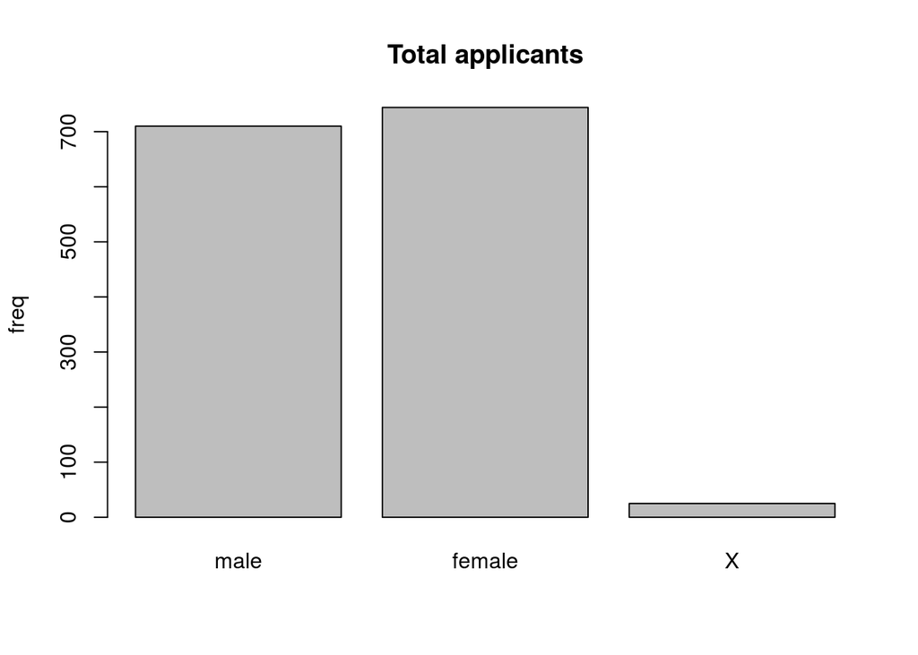

```r
  # Proportion of male vs female candidates
  barplot(c(sum(data2013$gender=="male"),sum(data2013$gender=="female"),sum(data2013$gender=="X")),names.arg  = c("male","female","X"),main = "Total applicants", ylab = "freq")
```

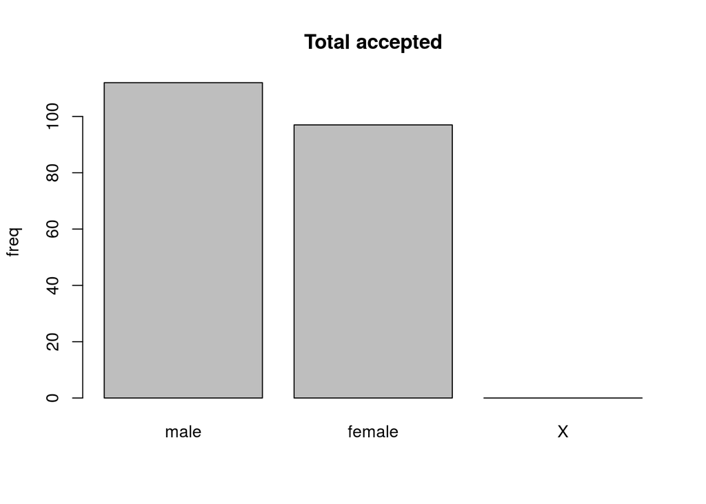

```r
  # Absolute acceptance by gender
   barplot(c(sum(data2013$gender=="male" & data2013$Status3=="Yes"),sum(data2013$gender=="female" & data2013$Status3=="Yes"),sum(data2013$gender=="X" & data2013$Status3=="Yes")),names.arg = c("male","female","X"),main = "Total accepted", ylab = "freq")
```

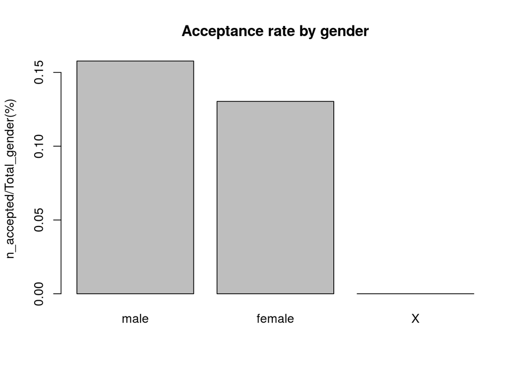

```r
  # Acceptance rate by gender
   barplot(c(sum(data2013$gender=="male" & data2013$Status3=="Yes")/sum(data2013$gender=="male"),sum(data2013$gender=="female" & data2013$Status3=="Yes")/sum(data2013$gender=="female"),sum(data2013$gender=="X" & data2013$Status3=="Yes")/sum(data2013$gender=="X")), names.arg  = c("male","female","X"),main = "Acceptance rate by gender", ylab = "n_accepted/Total_gender(%)")
```

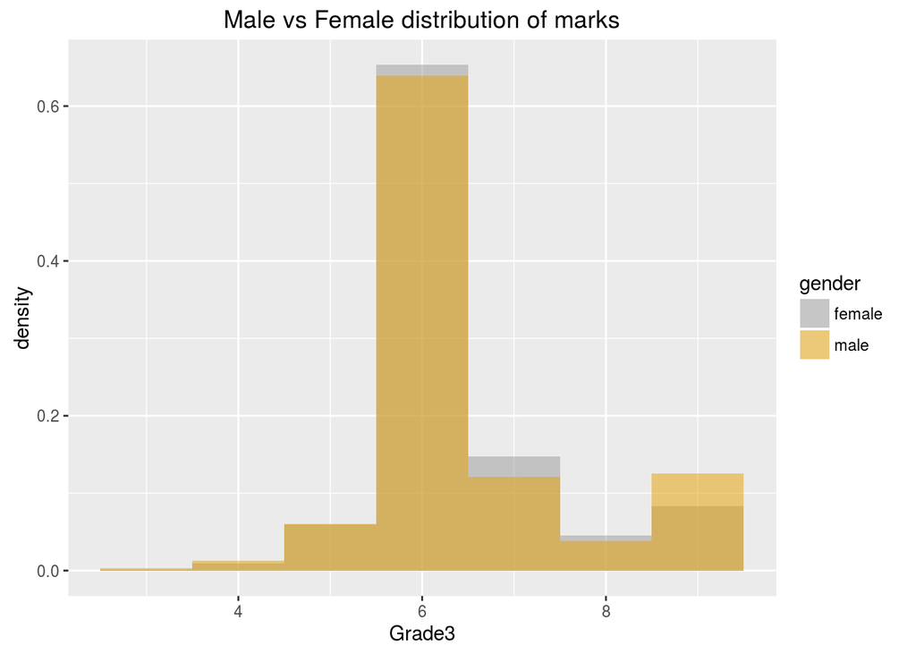

```r
  # distribution of marks per gender
  ggplot(data2013[data2013$gender!="X",c("Grade3","gender")], aes(Grade3, fill = gender)) + geom_histogram(alpha = 0.5, aes(y = ..density..), position = 'identity',binwidth = 1)+ ggtitle("Male vs Female distribution of marks") +scale_fill_manual(values=c("#999999", "#E69F00"))
```

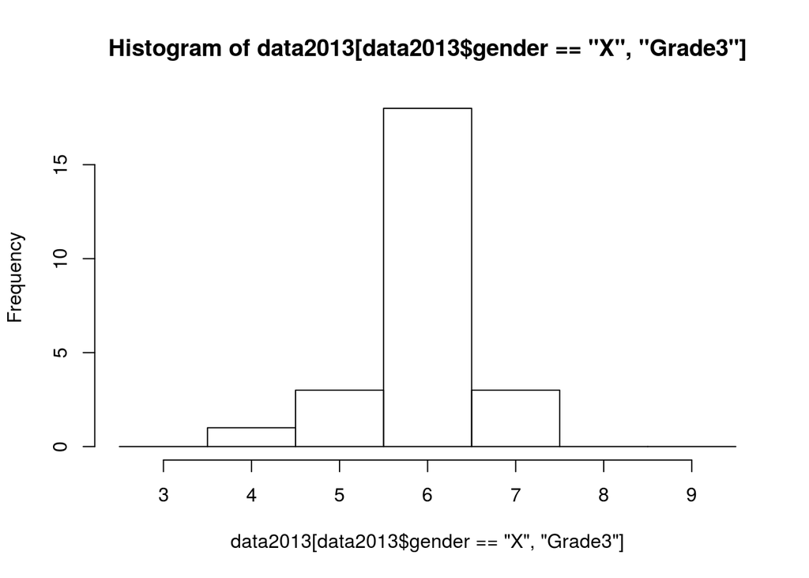

```r
  hist(data2013[data2013$gender=="X","Grade3"],seq(2.5,9.5,by = 1))
```

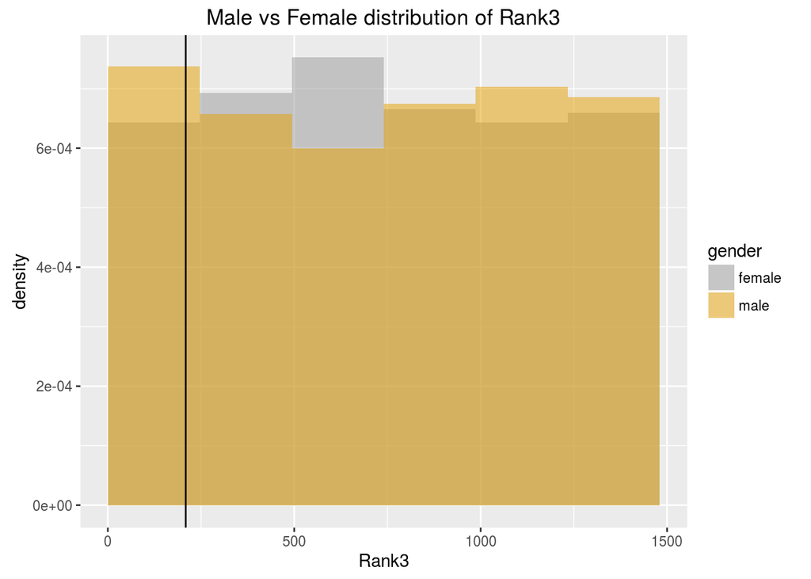

```r
  # distribution of rankings per gender

  ggplot(data2013[data2013$gender!="X",c("Rank3","gender")], aes(Rank3, fill = gender)) + geom_histogram(alpha = 0.5, aes(y = ..density..), position = 'identity',binwidth = dim(data2013)[1]/6, boundary = 0.5)+ ggtitle("Male vs Female distribution of Rank3") +scale_fill_manual(values=c("#999999", "#E69F00"))+ geom_vline(xintercept = 209)
```

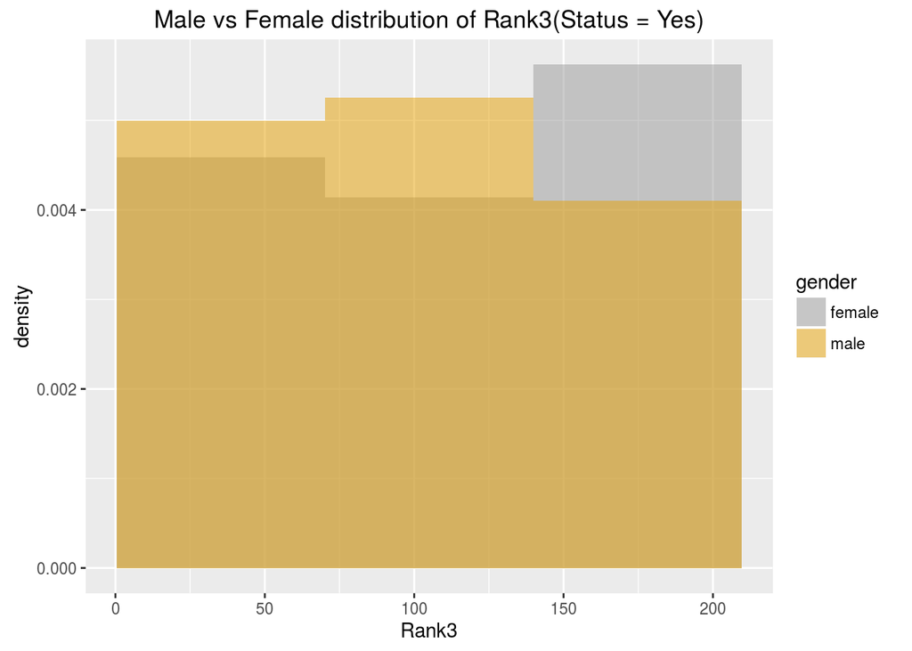

```r
    ggplot(data2013[data2013$gender!="X" & data2013$Status3=="Yes",c("Rank3","gender")], aes(Rank3, fill = gender)) + geom_histogram(alpha = 0.5, aes(y = ..density..), position = 'identity',binwidth = dim(data2013[data2013$gender!="X" & data2013$Status3=="Yes",c("Rank3","gender")])[1]/3, boundary = 0.5)+ ggtitle("Male vs Female distribution of Rank3(Status = Yes)") +scale_fill_manual(values=c("#999999", "#E69F00"))
```

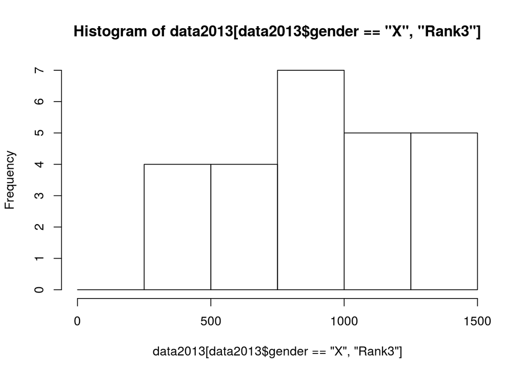

```r
  hist(data2013[data2013$gender=="X","Rank3"], seq(0,1500,by = 250))
```

Facts:

- The acceptance rate is larger for the male geender
- The distribution of marks is such that the male gender has higher marks
- Following these, there is an excess of higher rankings for men compared to women

Q? Is there gender discrimination? This call is not conclusive because I cannot split by areas. For example it may be the case that “male” apply to areas where the acceptance rate is higher but equal for “female”. We need to look into the following years where this information is available.

### 2.2.2 IF2014

In this call we have more details in the data.

```r
  head(data2014)
```

```
##             Ref                                   Name
## 1 IF/00003/2014 Luís Miguel Nunes Valente Afonso Reino
## 2 IF/00004/2014                           Karine Serre
## 3 IF/00006/2014                Manuel Algarra Gonzalez
## 4 IF/00007/2014                      Adria Gil Mestres
## 5 IF/00008/2014                    André Gama Oliveira
## 6 IF/00009/2014              Luís Miguel Teodoro Frija
##                                                                                 Host
## 1 Rede de Investigação em Biodiversidade e Biologia Evolutiva (InBIO/ICETA-Porto/UP)
## 2                                        Instituto de Medicina Molecular (IMM/FM/UL)
## 3                                    Centro de Investigação em Química (CIQ/FCUP/UP)
## 4                            Faculdade de Ciências da Universidade de Lisboa (FC/UL)
## 5                                           Centro de Matemática (CM/ADFCUP/FCUP/UP)
## 6                                         Centro de Química Estrutural (CQE/IST/UTL)
##   Panel Grade1 Rank1 Status1 Grade2 Rank2 Status2 Grade3 Rank3 Status3
```

[output cut: 20 more lines]

Let us first add the gender information. We create a column for this field

```r
  data2014$gender <- rep("X",dim(data2014)[1])
  head(data2014)
```

[output not shown]

and provisionally fill it using the gender resolution list that we already produced:

```r
  for (i in 1:dim(data2014)[1]) {
    full_name <- as.character(data2014$Name[i])
    first_name <- as.character(strsplit(full_name,split = " ")[[1]][1])
    list_pos <- first_name==gender_results_final$Name
    if(sum(list_pos)==1)
      data2014[i,"gender"]<-gender_results_final[list_pos,"gender"]
  }
  head(data2014[,c("Name","gender")])
```

```
##                                     Name gender
## 1 Luís Miguel Nunes Valente Afonso Reino   male
## 2                           Karine Serre female
## 3                Manuel Algarra Gonzalez   male
## 4                      Adria Gil Mestres      X
## 5                    André Gama Oliveira   male
## 6              Luís Miguel Teodoro Frija   male
```

```r
  head(data2014[data2014$gender=="X",c("Name","gender")])
```

```
##                               Name gender
## 4                Adria Gil Mestres      X
## 8                      RIBOT Julie      X
## 16 Andrea Patricia Ribeiro da Cruz      X
## 21                    Andrea Zille      X
## 35            Vardan Zh. Adibekyan      X
## 72  Leanete Teresinha Thomas Dotta      X
```

```r
  dim(data2014[data2014$gender=="X",c("Name","gender")])
```

```
## [1] 61  2
```

```r
  data2014[data2014$gender=="X",c("Name","gender")]
```

```
##                                       Name gender
## 4                        Adria Gil Mestres      X
## 8                              RIBOT Julie      X
## 16         Andrea Patricia Ribeiro da Cruz      X
## 21                            Andrea Zille      X
## 35                    Vardan Zh. Adibekyan      X
## 72          Leanete Teresinha Thomas Dotta      X
## 106                      Chitta Ranjan Das      X
## 110                   Arie van der Meijden      X
## 111                        Lozza Valentina      X
## 213                                Ying Ma      X
## 222         Andrea Catalina Galvis Sanchez      X
## 234                        Dixan Peña Peña      X
## 272              Christin-Melanie Vauclair      X
## 332                     Kim Richard Larsen      X
```

[output cut: 47 more lines]

and resolve most of the cases in the next code chunk

```r
  data2014[4,"gender"]<-"male"
  data2014[8,"gender"]<-"female"
  data2014[21,"gender"]<-"male"
  data2014[35,"gender"]<-"male"
  data2014[72,"gender"]<-"female"
  data2014[110,"gender"]<-"male"
  data2014[111,"gender"]<-"female"
  data2014[213,"gender"]<-"female"
  data2014[222,"gender"]<-"female"
  data2014[234,"gender"]<-"male"
  data2014[272,"gender"]<-"female"
  data2014[332,"gender"]<-"male"
  data2014[354,"gender"]<-"female"
  data2014[401,"gender"]<-"male"
  data2014[408,"gender"]<-"male"
  data2014[433,"gender"]<-"female"
  data2014[483,"gender"]<-"female"
  data2014[550,"gender"]<-"female"
  data2014[589,"gender"]<-"male"
  data2014[597,"gender"]<-"male"
  data2014[643,"gender"]<-"male"
  data2014[721,"gender"]<-"female"
  data2014[833,"gender"]<-"female"
  data2014[865,"gender"]<-"female"
  data2014[882,"gender"]<-"female"
  data2014[912,"gender"]<-"male"
  data2014[921,"gender"]<-"male"
  data2014[982,"gender"]<-"male"
  data2014[995,"gender"]<-"female"
  data2014[1008,"gender"]<-"male"
  data2014[1028,"gender"]<-"female"
  data2014[1040,"gender"]<-"male"
  data2014[1085,"gender"]<-"female"
  data2014[1132,"gender"]<-"male"
  data2014[1136,"gender"]<-"male"
  data2014[1153,"gender"]<-"female"
  data2014[1184,"gender"]<-"male"
  data2014[1187,"gender"]<-"female"
  data2014[1209,"gender"]<-"male"
  data2014[1231,"gender"]<-"male"
  data2014[1246,"gender"]<-"male"
  data2014[1265,"gender"]<-"male"
  data2014[1279,"gender"]<-"male"
  data2014[1306,"gender"]<-"female"
  data2014[1314,"gender"]<-"male"
  data2014[1363,"gender"]<-"male"
  data2014[1377,"gender"]<-"male"
  data2014[1382,"gender"]<-"female"
```

The percentage of candidates with undetermined gender is again small:

```r
  sum(data2014$gender=="X")*100./dim(data2014)[1]
```

```
## [1] 0.9298999
```

**Global distributions**

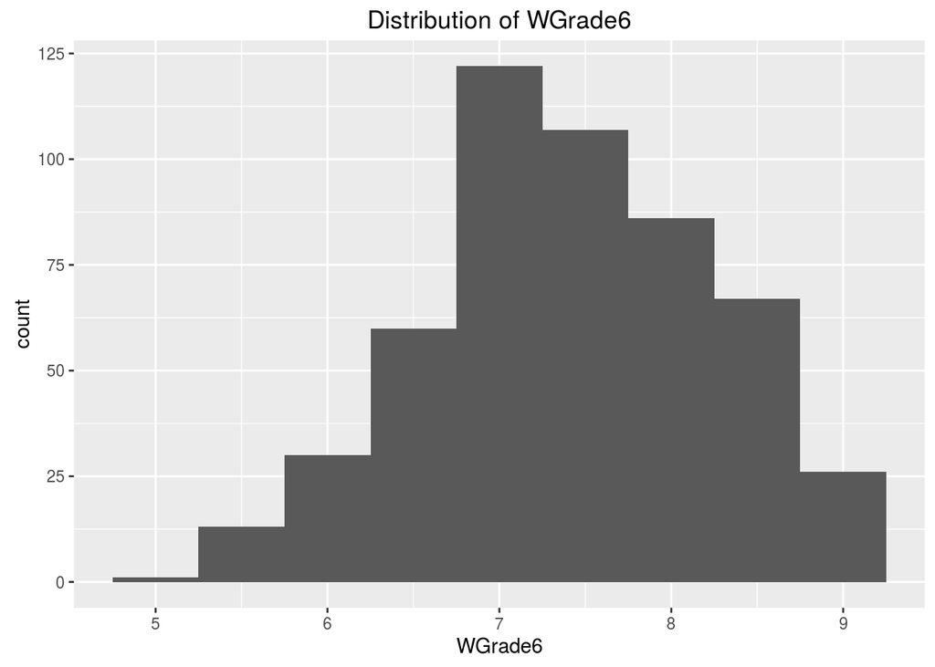

```r
  # Distribution of final marks
  ggplot(data2014[!is.na(data2014$WGrade6),c("WGrade6","gender")], aes(WGrade6)) + geom_histogram(binwidth = 0.5)+ ggtitle("Distribution of WGrade6")
```

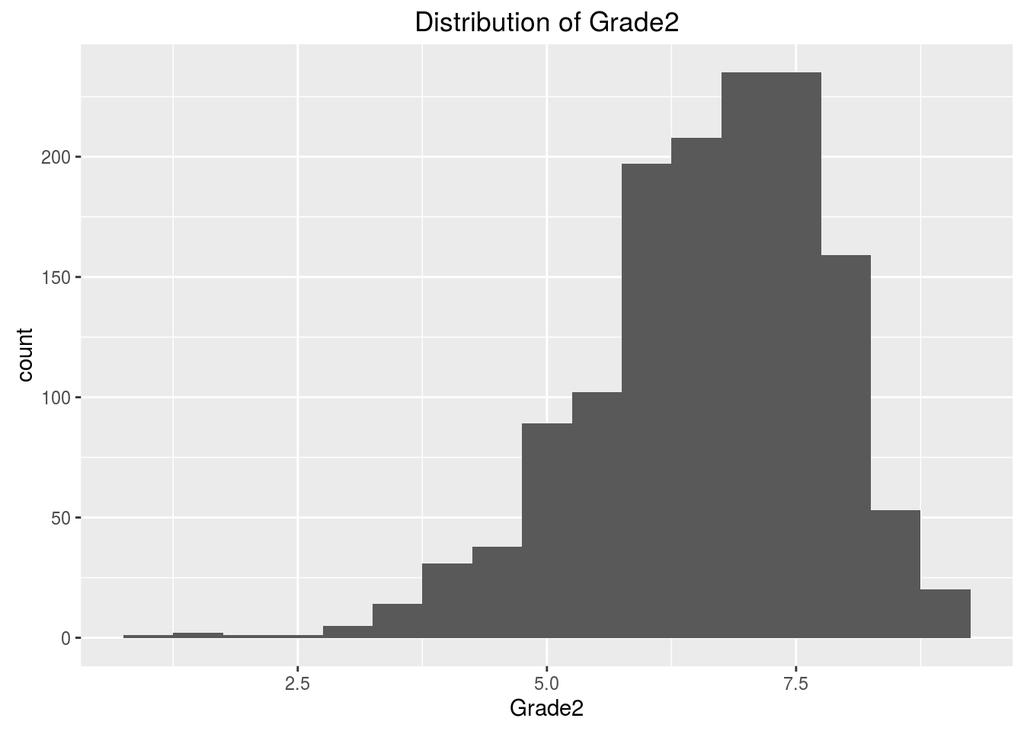

```r
  # Distribution of intermediate marks
  ggplot(data2014[!is.na(data2014$Grade2),c("Grade2","gender")], aes(Grade2)) + geom_histogram(binwidth = 0.5)+ ggtitle("Distribution of Grade2")
```

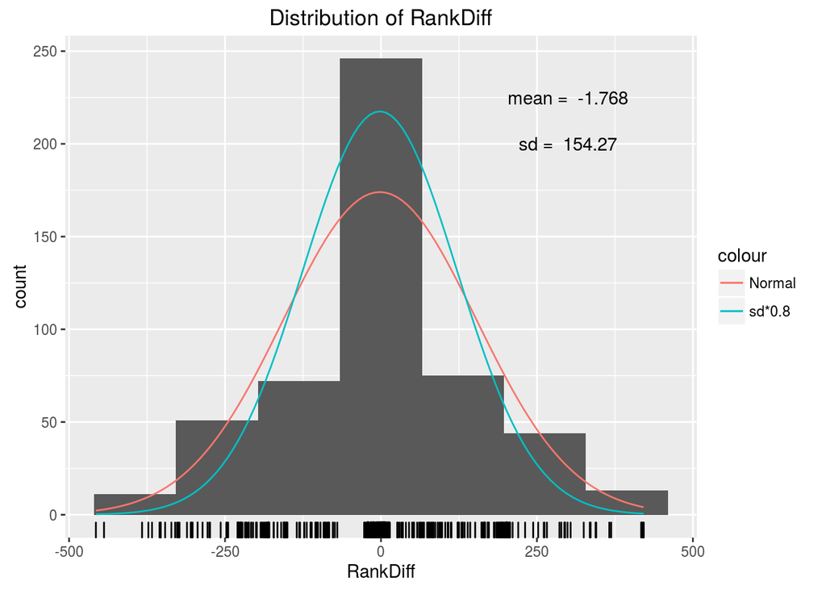

```r
  # Variations in ranking between stage 1 and 2
  rankdiff2014 <- data2014[!is.na(data2014$Rank6),c("Rank3","Rank6")]
  rankdiff2014$RankDiff <-rankdiff2014$Rank6-rankdiff2014$Rank3

  mean_rankdiff2014 <- mean(rankdiff2014$RankDiff)
  sd_rankdiff2014 <-sd(rankdiff2014$RankDiff)
  bin_rankdiff2014 <-2*460/7
    #2*dim(rankdiff2014)[1]/6
  factor_rankdiff2014 <- dim(rankdiff2014)[1]*bin_rankdiff2014
  gaussrankdiff2014 <- function(x){
    factor_rankdiff2014*dnorm(x,mean_rankdiff2014,sd_rankdiff2014)
  }
  gaussrank2diff2014 <- function(x){
    factor_rankdiff2014*dnorm(x,mean_rankdiff2014,0.8*sd_rankdiff2014)
  }
  ggplot(rankdiff2014, aes(RankDiff)) + geom_histogram(binwidth = bin_rankdiff2014,boundary =-460 )+geom_rug()+stat_function(fun = gaussrankdiff2014, aes(colour = 'Normal'))+stat_function(fun = gaussrank2diff2014, aes(colour = 'sd*0.8'))+ ggtitle("Distribution of RankDiff")+annotate("text", x = 300, y = 225, label = paste("mean = ",as.character(round(mean_rankdiff2014,3))))+annotate("text", x = 300, y = 200, label = paste("sd = ",as.character(round(sd_rankdiff2014,3))))
```

This distribution does not seem to follow a gaussian. It seems to be more peaky around the center, meaning a higher frequency for the rank to remain the same rather than varying a lot. Nevertheless the distribution has quite “fat” tails. Maybe see https://en.wikipedia.org/wiki/Rank_correlation ???

**Gender distributions**

1. Acceptance rates

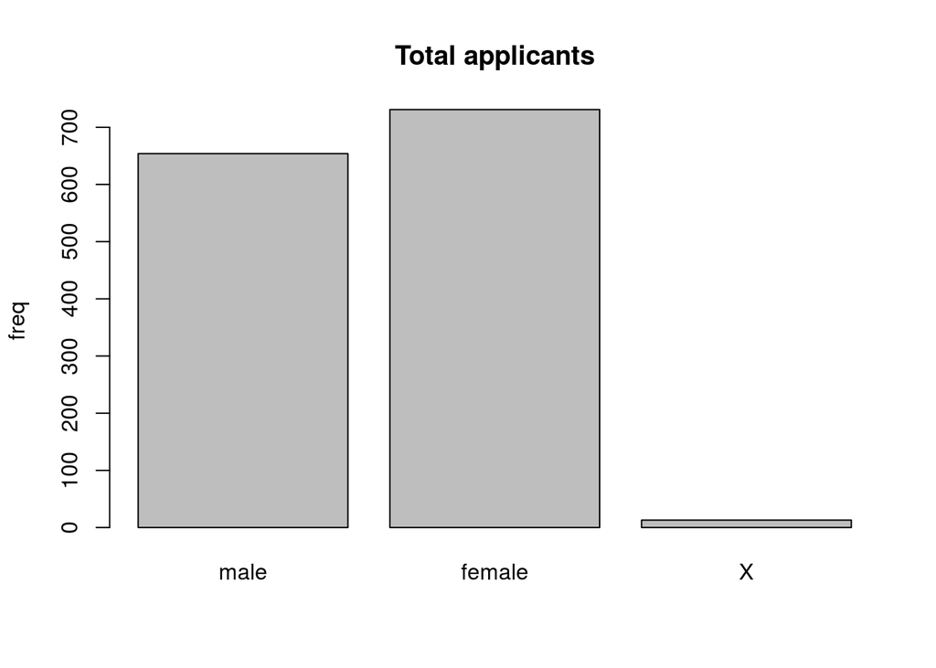

```r
  # Proportion of male vs female candidates
  barplot(c(sum(data2014$gender=="male"),sum(data2014$gender=="female"),sum(data2014$gender=="X")),names.arg= c("male","female","X"),main = "Total applicants",ylab = "freq")
```

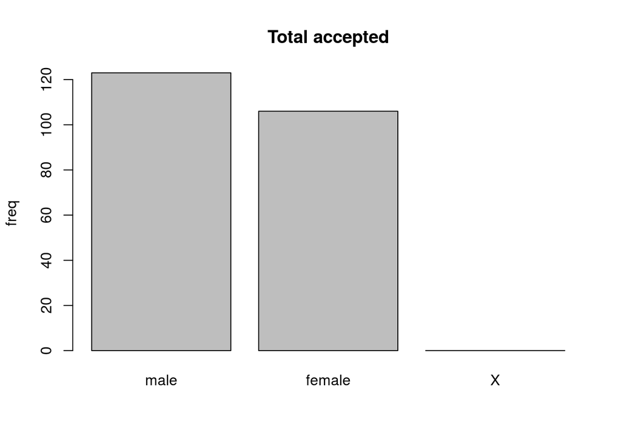

```r
  # Absolute acceptance by gender
   barplot(c(sum(data2014$gender=="male" & data2014$Status6=="Yes"),sum(data2014$gender=="female" & data2014$Status6=="Yes"),sum(data2014$gender=="X" & data2014$Status6=="Yes")),names.arg = c("male","female","X"),main = "Total accepted",ylab = "freq")
```

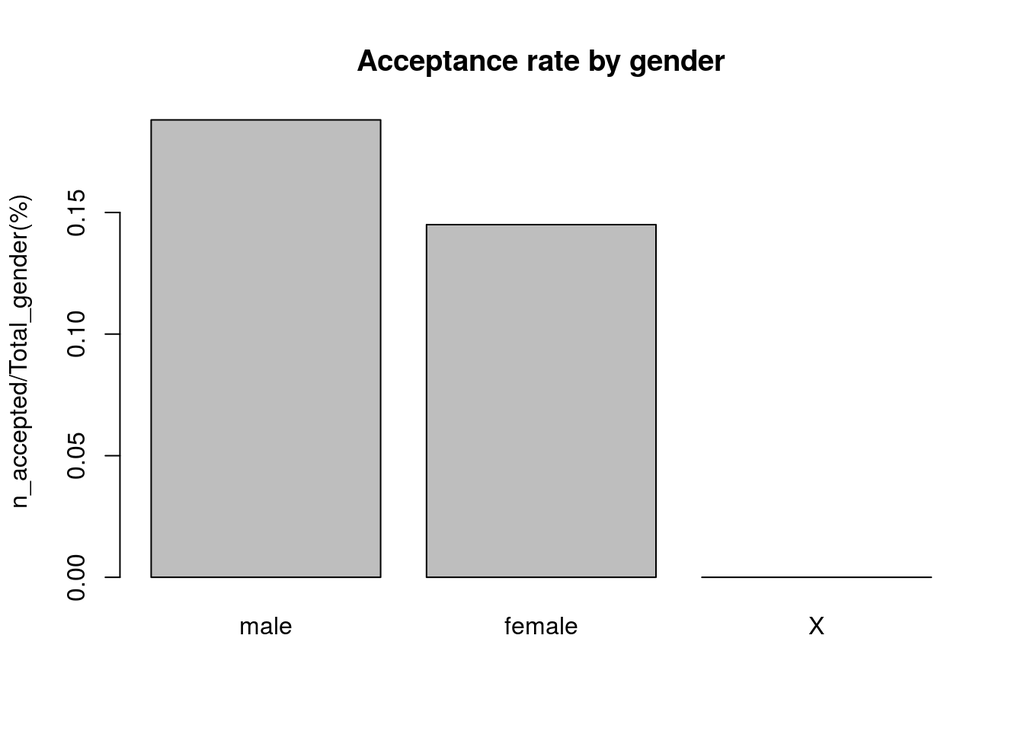

```r
  # Acceptance rate by gender
   barplot(c(sum(data2014$gender=="male" & data2014$Status6=="Yes")/sum(data2014$gender=="male"),sum(data2014$gender=="female" & data2014$Status6=="Yes")/sum(data2014$gender=="female"),sum(data2014$gender=="X" & data2014$Status6=="Yes")/sum(data2014$gender=="X")),names.arg  = c("male","female","X"),main = "Acceptance rate by gender", ylab = "n_accepted/Total_gender(%)")
```

2. Distribution of Grades

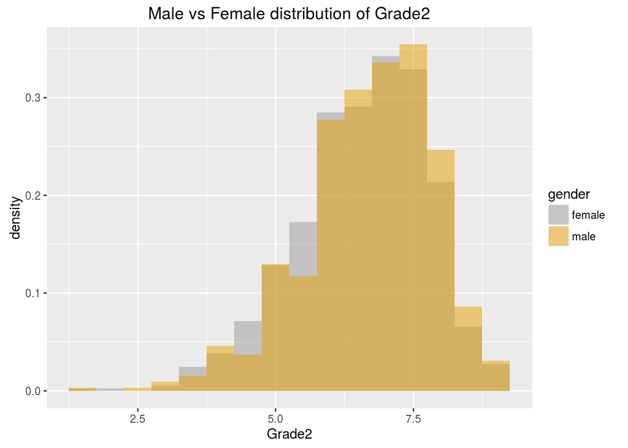

```r
  # distribution of marks per gender
  ggplot(data2014[data2014$gender!="X" & !is.na(data2014$Grade2),c("Grade2","gender")], aes(Grade2, fill = gender)) + geom_histogram(alpha = 0.5, aes(y = ..density..), position = 'identity',binwidth = 0.5)+ ggtitle("Male vs Female distribution of Grade2") +scale_fill_manual(values=c("#999999", "#E69F00"))
```

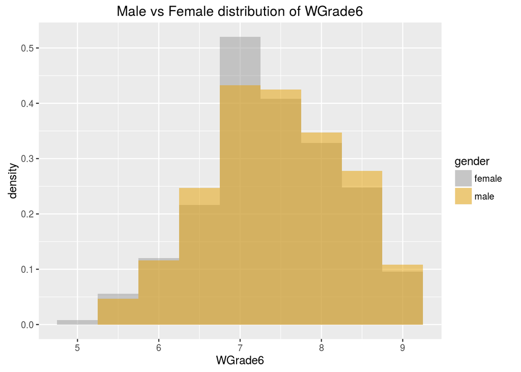

```r
  ggplot(data2014[data2014$gender!="X" & !is.na(data2014$WGrade6),c("WGrade6","gender")], aes(WGrade6, fill = gender)) + geom_histogram(alpha = 0.5, aes(y = ..density..), position = 'identity',binwidth = 0.5)+ ggtitle("Male vs Female distribution of WGrade6") +scale_fill_manual(values=c("#999999", "#E69F00"))
```

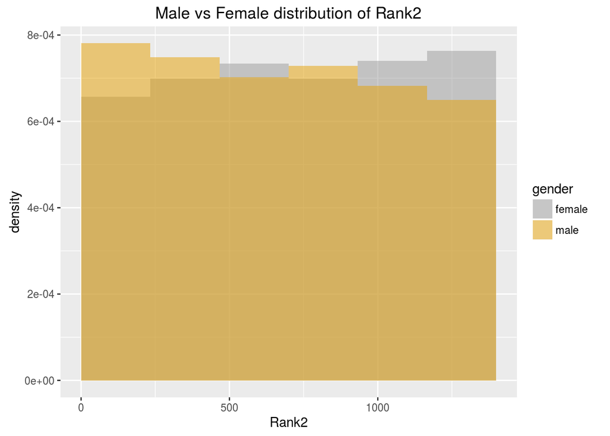

```r
# distribution of Rank2 per gender
  ggplot(data2014[data2014$gender!="X",c("Rank2","gender")], aes(Rank2, fill = gender)) + geom_histogram(alpha = 0.5, aes(y = ..density..), position = 'identity',binwidth = dim(data2014)[1]/6, boundary = 0.5)+ ggtitle("Male vs Female distribution of Rank2") +scale_fill_manual(values=c("#999999", "#E69F00"))
```

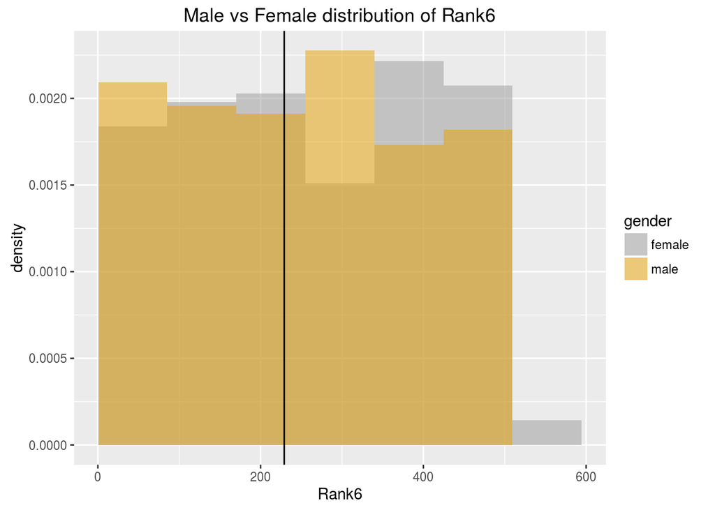

```r
# distribution of Rank6 per gender
  ggplot(data2014[data2014$gender!="X" & !is.na(data2014$Rank6),c("Rank6","gender")], aes(Rank6, fill = gender)) + geom_histogram(alpha = 0.5, aes(y = ..density..), position = 'identity',binwidth = dim(data2014[data2014$gender!="X" & !is.na(data2014$Rank6),c("Rank6","gender")])[1]/6, boundary = 0.5)+ ggtitle("Male vs Female distribution of Rank6")+geom_vline(xintercept = 229) +scale_fill_manual(values=c("#999999", "#E69F00"))
```

```r
  #hist(data2014[data2014$gender=="X","WGrade6"])

  # distribution of rankings per gender
  #hist(data2014[data2014$gender=="female","Rank6"],seq(0,1500,by = 250))
  #hist(data2014[data2014$gender=="male","Rank6"], seq(0,1500,by = 250))
  #hist(data2014[data2014$gender=="X","Rank6"], seq(0,1500,by = 250))
```

I think that in the last plot there is an effect from candidates in special conditions in the last bin. CHECK THIS AND THINK IF I SHOULD REMOVE FROM ANALYSIS.

3. Plots by panel

Now we are going to investigate if there is gender discrimination in each panel. There is a problem however! We do not have panel information for candiates rejected in the first stage. This is relevant because if there is gender descrimination at the first stage then we cannot compute the relative frequency (because we need to divide by the population size for the given gender). Furthermore, even if we focus on gender discrimination at stage2, the effect will a priori be smaller because if the discrimination criteria follows the same procedure, then the candidates in the discriminated gender are already, on average, of a higher quality by precisely the factor that makes them equal, on average, to the candidates of the other gender in the eyes of the evaluators.

Let us make some plots to see what happens if we focus on the sub-population of candidates for whom we have panel information (i.e. stage2 candidates).

We look at the density plots (density means divided by the number of candidates in these plots for the given gender) versus the absolute frequency plots

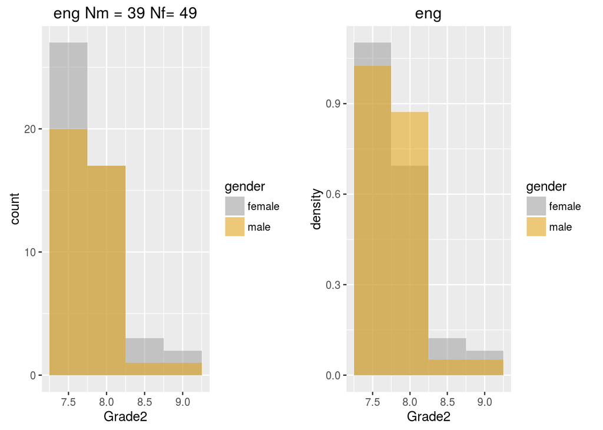

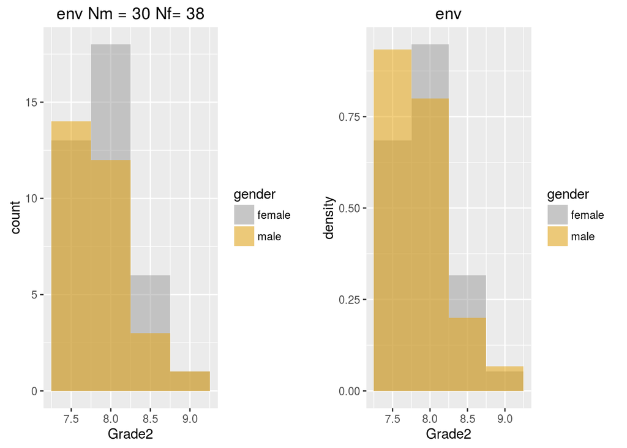

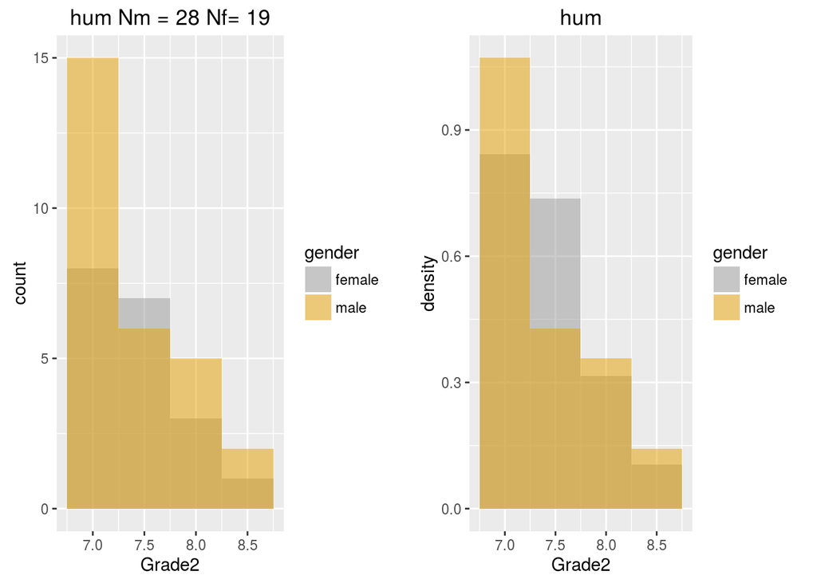

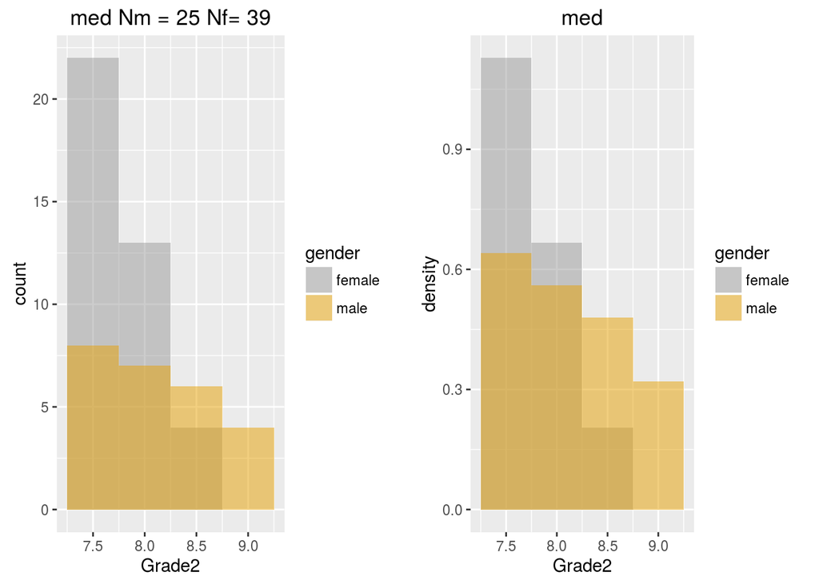

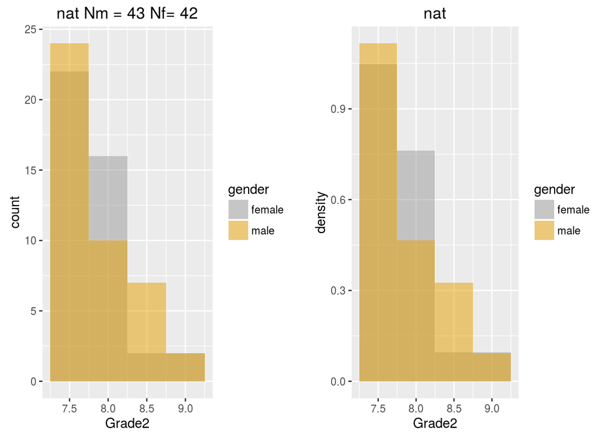

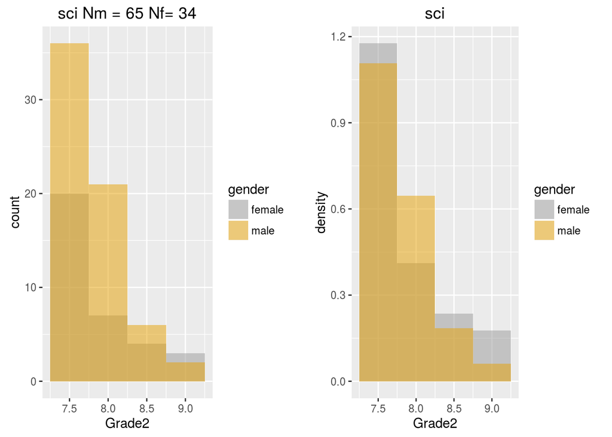

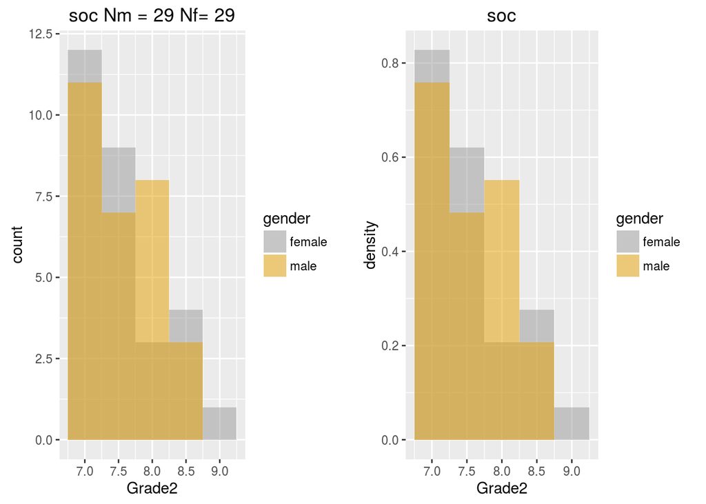

```r
  # Distributions of grades by gender at the end of stage 1 for each panel
  panel_names <- levels(data2014$Panel)[levels(data2014$Panel)!="empty"]
  i<-0
  for (panel_name in panel_names) {
    i<-i+1
    #plots_list[[i]]<-
    data_temp<-data2014[data2014$gender!="X" & !is.na(data2014$Grade2) & data2014$Panel==panel_name,c("Grade2","gender")]
    p1<-ggplot(data_temp, aes(Grade2, fill = gender)) + geom_histogram(alpha = 0.5, position = 'identity',binwidth = 0.5)+ ggtitle(paste(panel_name, "Nm =",as.character(sum(data_temp$gender=="male")),"Nf=",as.character(sum(data_temp$gender=="female")))) + scale_fill_manual(values=c("#999999", "#E69F00"))
    p2<-ggplot(data2014[data2014$gender!="X" & !is.na(data2014$Grade2) & data2014$Panel==panel_name,c("Grade2","gender")], aes(Grade2, fill = gender)) + geom_histogram(alpha = 0.5, aes(y = ..density..), position = 'identity',binwidth = 0.5)+ ggtitle(panel_name) + scale_fill_manual(values=c("#999999", "#E69F00"))
    multiplot(p1, p2, cols = 2)
  }
```

We see that it is hard to draw a conclusion because to interpret the fluctuations in Grade2 we also need the rest of the population to compute a meaningful density.

If we focus on stage 2 now. We can at the same plots for WGrade6:

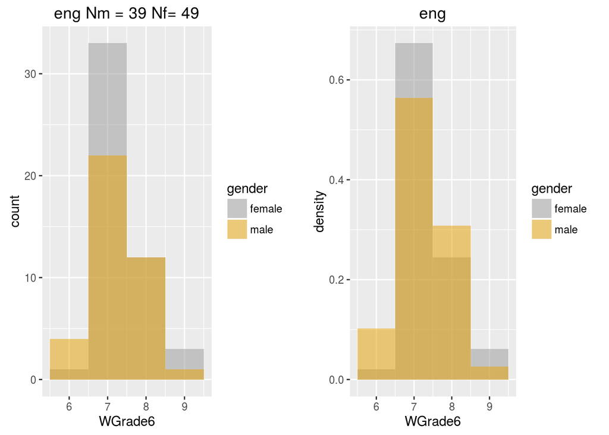

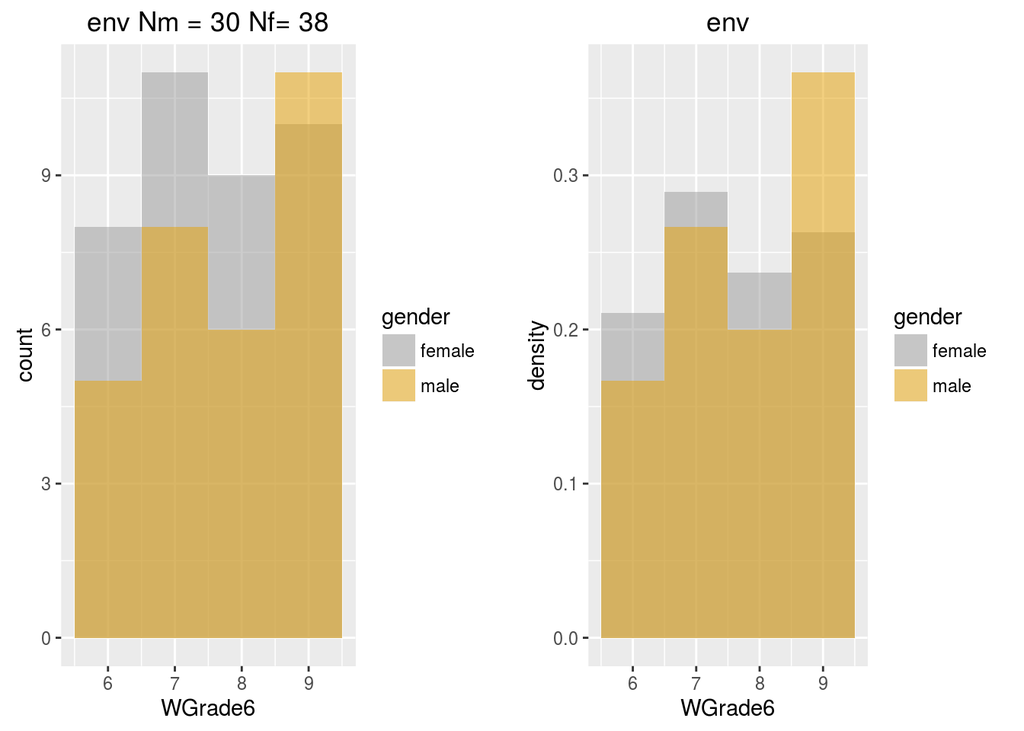

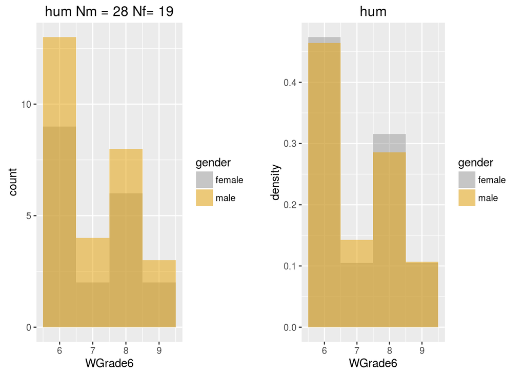

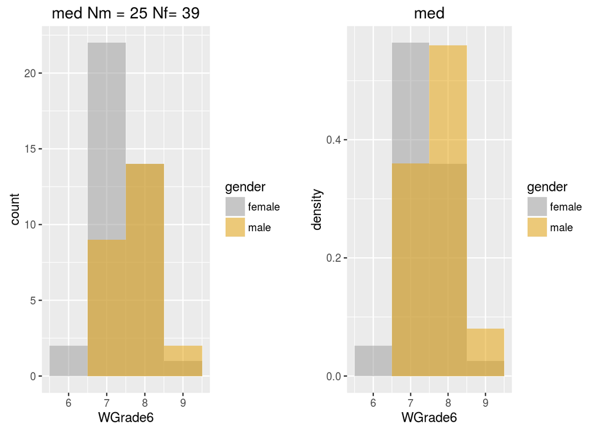

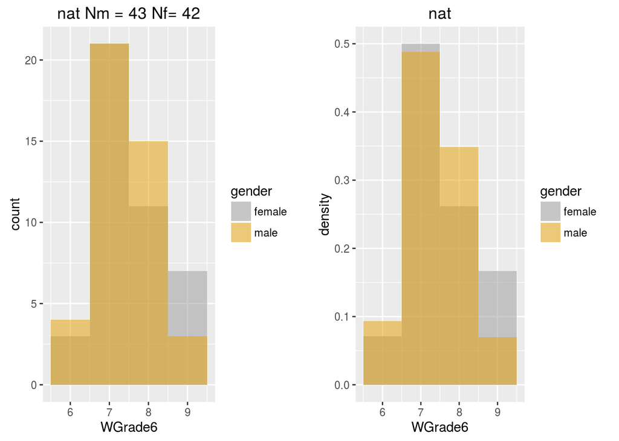

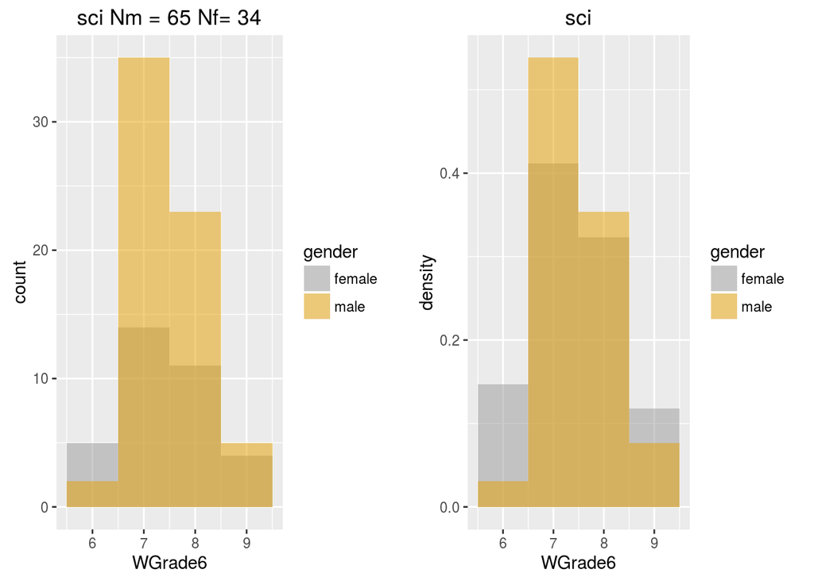

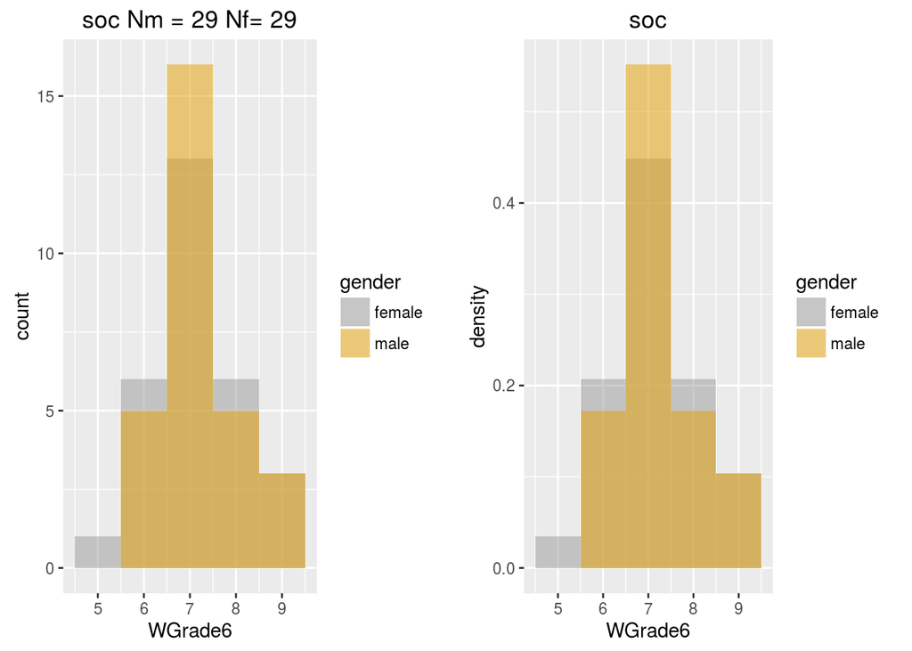

```r
  # Distributions of grades by gender at the end of stage 2 for each panel
  panel_names <- levels(data2014$Panel)[levels(data2014$Panel)!="empty"]
  i<-0
  for (panel_name in panel_names) {
    i<-i+1
    #plots_list[[i]]<-
    data_temp<-data2014[data2014$gender!="X" & !is.na(data2014$WGrade6) & data2014$Panel==panel_name,c("WGrade6","gender")]
    p1<-ggplot(data_temp, aes(WGrade6, fill = gender)) + geom_histogram(alpha = 0.5, position = 'identity',binwidth = 1)+ ggtitle(paste(panel_name, "Nm =",as.character(sum(data_temp$gender=="male")),"Nf=",as.character(sum(data_temp$gender=="female")))) + scale_fill_manual(values=c("#999999", "#E69F00"))
    p2<-ggplot(data2014[data2014$gender!="X" & !is.na(data2014$WGrade6) & data2014$Panel==panel_name,c("WGrade6","gender")], aes(WGrade6, fill = gender)) + geom_histogram(alpha = 0.5, aes(y = ..density..), position = 'identity',binwidth = 1)+ ggtitle(panel_name) + scale_fill_manual(values=c("#999999", "#E69F00"))
    multiplot(p1, p2, cols = 2)
  }
```

We see that these sample per panel are all relatively small. In most panels there is no clear trend. Focusing on the panels with largest samples:

- For “eng”, the density distributions do not differ significantly. In particular it seems like for the grades above the threshold for funding (8 plus 9) the summed density is the same for both genders.
- For “env”, the situation is similar but with some excess for “male” for larger marks
- For the other panels the situation seems again even among genders, with the exception of the “med” panel for which there is a very large shift of the “male” density function for larger marks.

Next, let us look at the acceptance rate by gender on stage2